# Session 3

Case Study: Singapore’s Smart Nation, Open Government Products, and Singapore Government Tech Stack

[Ernest Guevarra](https://ernest.guevarra.io)

ernest@guevarra.io

[University of Oxford](https://www.tropicalmedicine.ox.ac.uk/study-with-us/msc-ihtm)

[figure not shown]

## Smart Nation journey

[figure not shown]

1963

[figure not shown]

1981

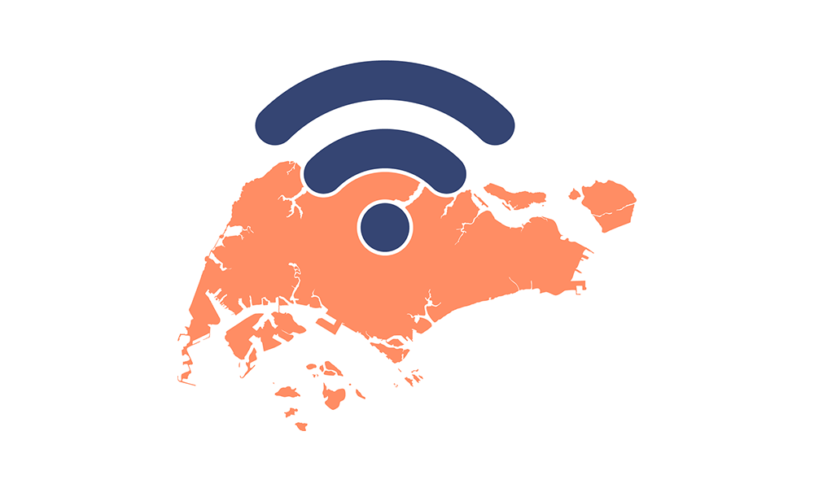

1997

[figure not shown]

2000

[figure not shown]

2007

[figure not shown]

2014

[figure not shown]

2016

[figure not shown]

2017

[figure not shown]

2018

[figure not shown]

2022

[figure not shown]

2023

[figure not shown]

2024

## Vision

- Singapore’s **Smart Nation initiative**, led by the Ministry of Digital Development and Information (MDDI), aims to build a thriving digital future for everyone.
- Launched in **2014**, Smart Nation 1.0 sought to improve lives through seamless and meaningful use of technology.
- Since its launch, Singapore has integrated digital technologies deeply into daily life, creating new opportunities while also needing to manage risks to well-being and social cohesion.
- In **2024**, Singapore introduced **Smart Nation 2.0**, a refreshed vision focused on using technology more effectively to transform the nation’s future.
- The new phase shifts from primarily building digital capabilities to applying them strategically to shape Singapore’s long-term development.

## Goals

## Trust

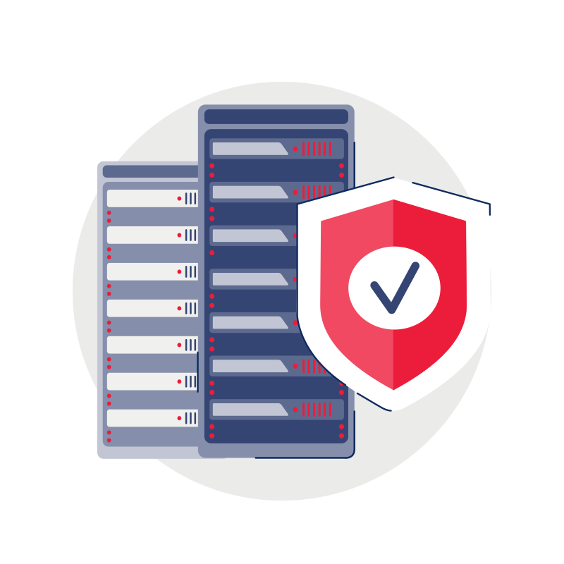

Enhance the security and resilience of our digital infrastructure

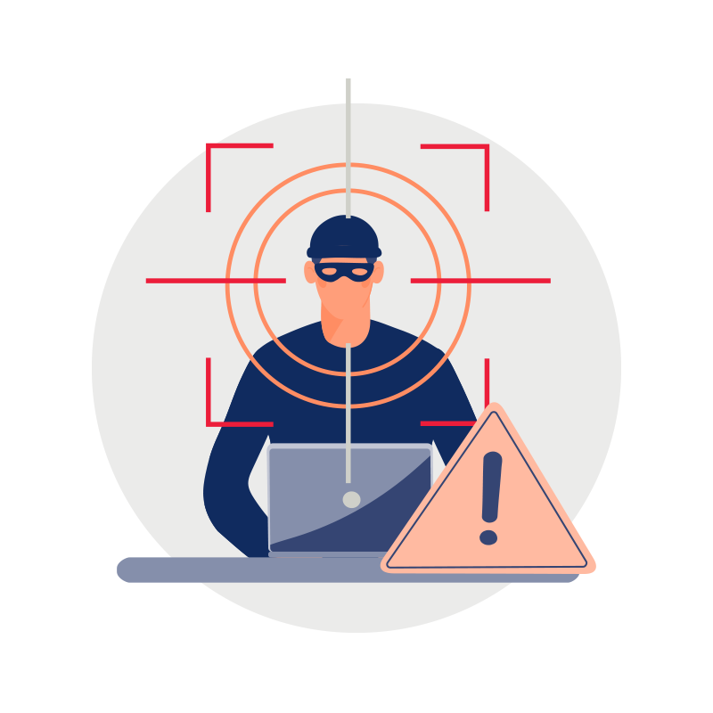

Strengthen our fight against harmful online activities

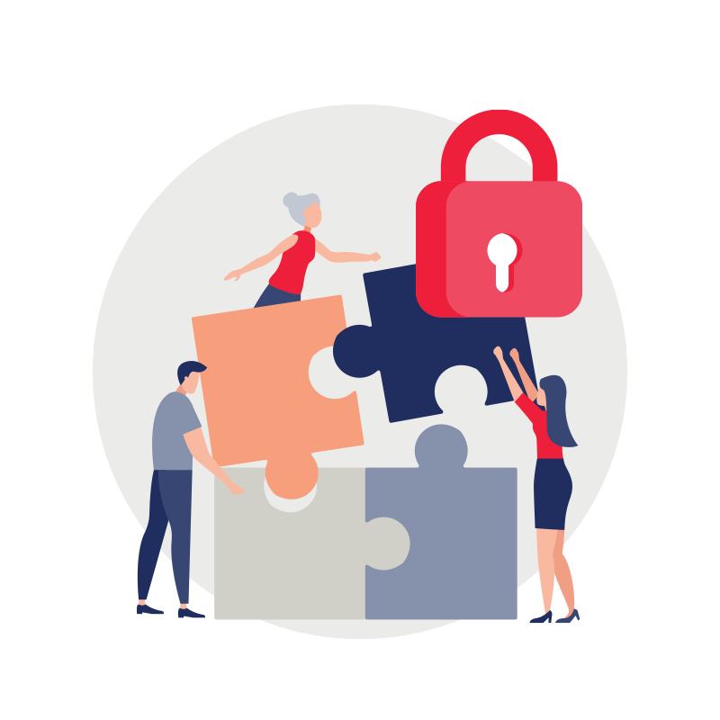

Expand our trusted digital spaces together

## Growth

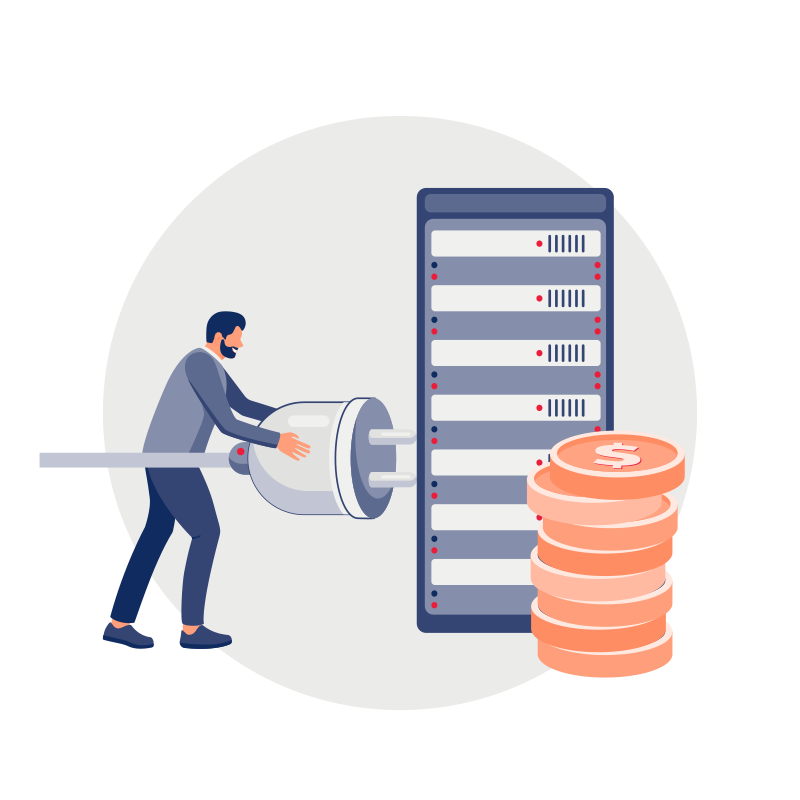

Power our digital economy

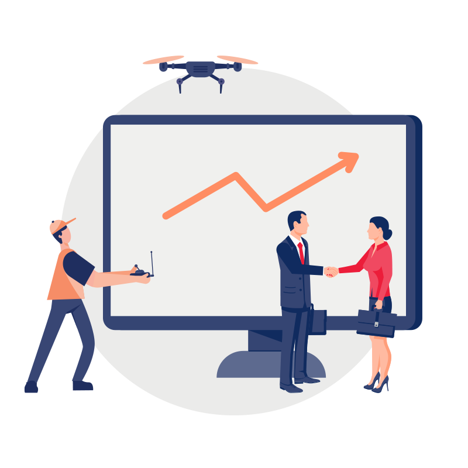

Empower our enterprises and workers

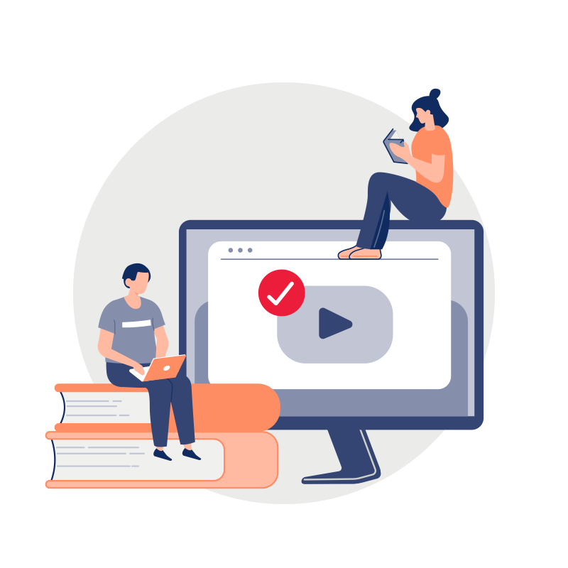

Prepare our next generation

## Community

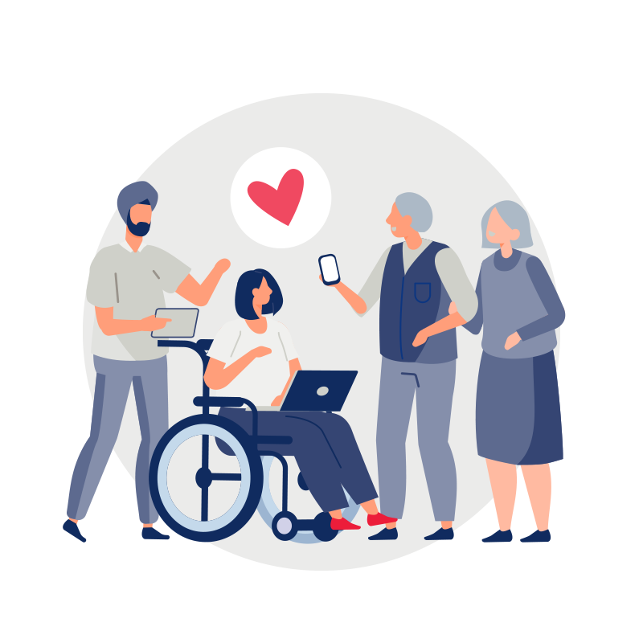

Strengthen inclusion: leaving no one behind

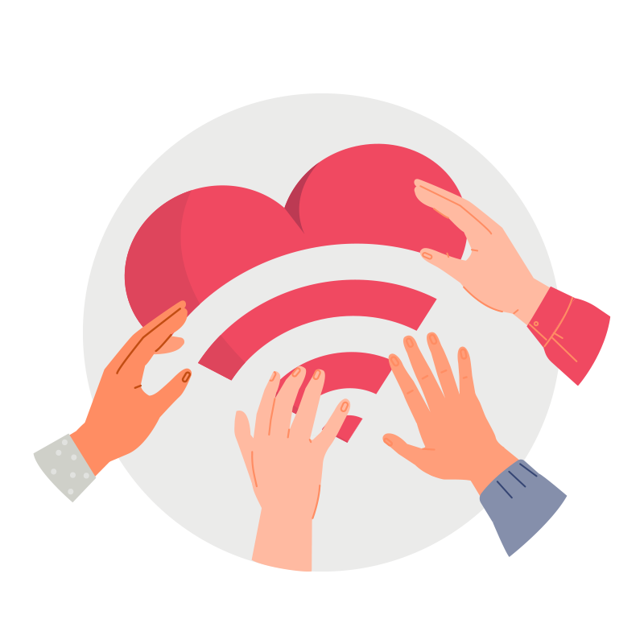

Strengthen the unity of our community

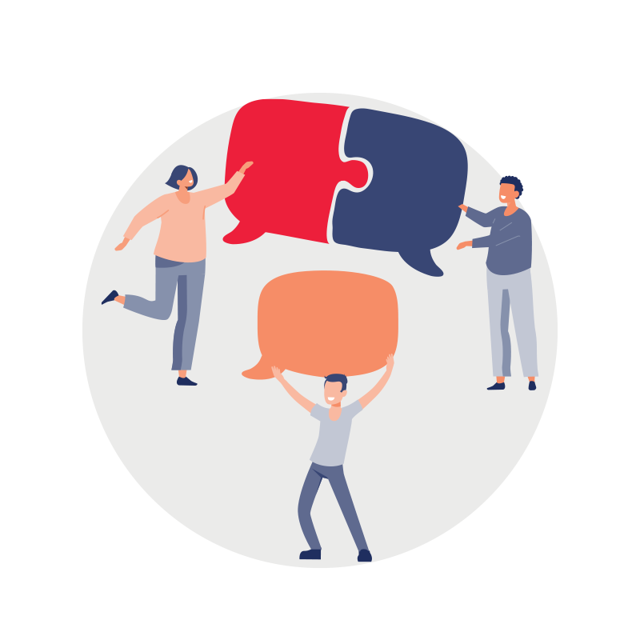

Strengthen partnerships with citizens

## Smart City achievements

- **99%** of all transactions between citizens and the government can be completed online.
- **High citizen and business satisfaction** with Government Digital Services at **83%** in 2023.
- **99%** of resident households are **connected to the internet**, as of 2022.
- **95%** of small and medium enterprises (SMEs) have adopted at least one digital technology from nine categories: cybersecurity, cloud, e-payment, e-commerce, data analytics, artificial intelligence, Internet of Things, blockchain, and immersive media.

## National AI Strategy

[figure not shown]

## Open Government Products

## Approach

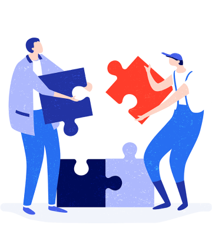

Solve real problems

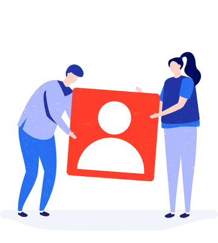

Build for the user

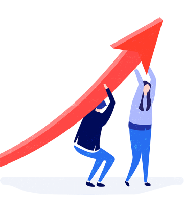

Push for change

## Products

- More than 40 products in progress
- Use **report cards** mechanism to provide a transparent overview of the work being done on each of the products

#### Tackle real problems

Share why and how the product solves a problem with updates along the way.

#### Resource responsibly

Product costs are made open as possible to stay accountable to taxpayers and citizens.

#### Track impact clearly

Share product outcomes to ensure delivery of clear value to the public.

[figure not shown]

- [**ScamShield**](https://www.scamshield.gov.sg/) helps users detect, check, and report suspicious messages, calls, and links.
- Reported scams are verified by authorities, helping them track and respond to new scam variants.

[figure not shown]

- Paper voucher campaigns were slow to launch and difficult for residents to claim and use.
- Merchants experienced long delays in receiving payments.
- Existing digital alternatives were available but scattered across multiple complicated apps.
- [**RedeemSG**](https://redeem.gov.sg/) provides a unified platform for government agencies and non-profits to create, distribute, and monitor vouchers nationwide.
- Citizens redeem vouchers and merchants accept them through the same system.

[figure not shown]

- Paper-based tracking made it difficult for organisations to monitor distributions or adapt plans in real time.
- This led to long waiting times, inaccurate records, and limited ability to reach more beneficiaries.
- [**DistributeSG**](https://distribute.gov.sg/) enables government agencies and non-profits to run and monitor distribution campaigns with real-time tracking.
- It includes an admin portal for organisers to set up campaigns and a mobile app for on-the-ground tracking of distributed items.

## Initiatives

[figure not shown]

- **Build for Good** is a citizen engagement initiative by Open Government Products that encourages citizens to help improve Singapore.
- People can participate through a **hackathon**, an **accelerator for winning teams**, or by joining the **community**.
- The initiative aims to create a supportive space where individuals feel empowered to contribute positively, experiment, and build solutions that make the world better.

[figure not shown]

- **Hack for Public Good (HFPG)** replaces top-down product development with a community-driven approach.
- Instead of leadership setting the direction, tech teams engage directly with the community to identify public good problems in Singapore.
- These teams then design and build solutions based on what they discover.

## Singapore government tech stack

## Overview

- The **Singapore Government Tech Stack (SGTS)** modernises development practices across the whole government.
- The goal is to support the creation of secure, responsive systems that keep up with evolving citizen and business needs.

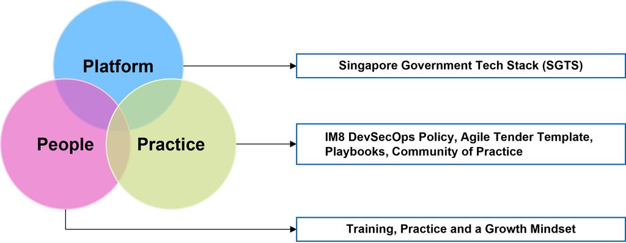

## Architecture

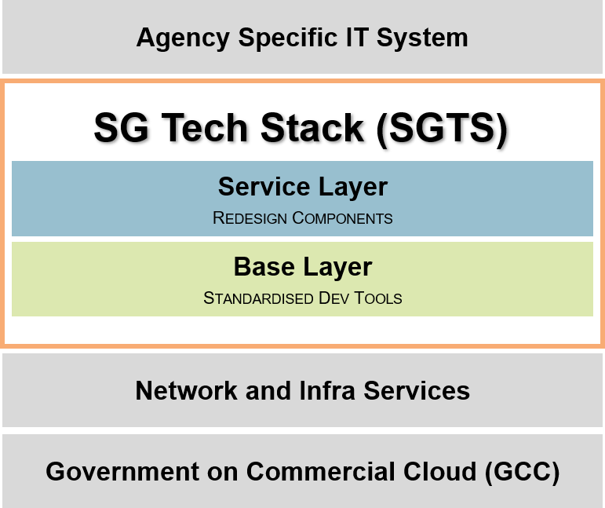

## Architecture - base layer

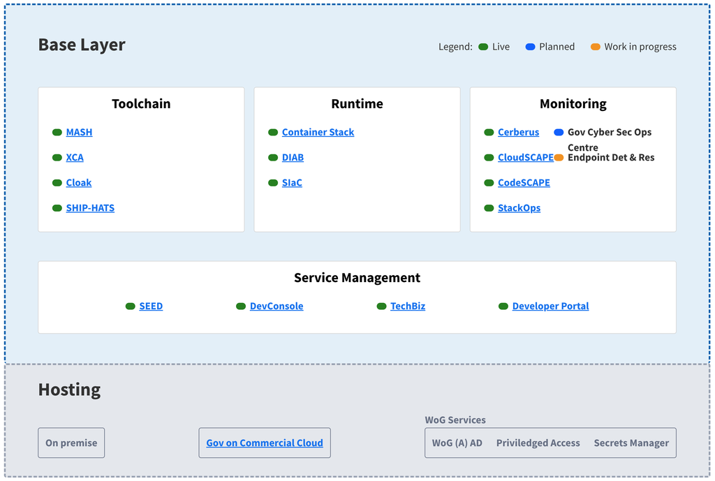